# WeRateDogs Twitter data

```python
from IPython.display import HTML

HTML('''<script>
code_show=true;
function code_toggle() {
 if (code_show){
 $('div.input').hide();
 } else {
 $('div.input').show();
 }
 code_show = !code_show
}
$( document ).ready(code_toggle);
</script>
The raw code for this IPython notebook is by default hidden for easier reading.
To toggle on/off the raw code, click <a href="javascript:code_toggle()">here</a>.''')
```

The raw code for this IPython notebook is by default hidden for easier reading. To toggle on/off the raw code, click here.

## Introduction

WeRateDogs is a super popular twitter handle that will brighten anyone's day (even if you are a cat lover). In an effort to understand it's popularity, I analyzed information pulled from the twitter API, data produced from an image predition algorithm and twitter archive data. Some questions I was hoping to answer were:

1. What is the relationship between retweet_count and favorite_count?
2. What is the relationship between confidence value and whether the image was identified?
3. Which breed of dogs gets most retweeted?
4. At what time of day do tweets get the most favorites?

## Data Wrangling and Cleaning

I read in the necessary files and utilized the Twitter API to pull tweet data. A few of the main cleaning tasks were to merge and delete unnecessary columns, correct datatypes, delete entries when data was missing, and clarify headers and data. I merged muliple dataframes together to have one succinct "twitter_archive_master.csv" file ready to be analyzed. The final data base was 1957 entries by 18 variables in size.

## Exploratory Data Analysis

### Retweets and Favorites

Let's look at the relationship between retweet count and favorite count with a scatter plot.

```python
import pandas as pd
import numpy as np
import requests
import tweepy
import json
import os
import sys
import datetime
import csv
from timeit import default_timer as timer
import seaborn as sb
import statsmodels.api as sm
import matplotlib.pyplot as plt
%matplotlib inline
from tweepy import OAuthHandler

# suppress warnings from final output
import warnings
warnings.simplefilter("ignore")
```

```python
df = pd.read_csv("twitter_archive_master.csv")
```

```python
twitter_archive_master = df.copy()
```

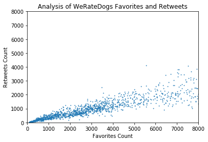

```python
# Scatter plot of favorites and retweets.
plt.xlim(0, 8000)
plt.ylim(0, 8000)
plt.scatter(data = twitter_archive_master, x = 'favorite_count', y = 'retweet_count', s = 0.7)
plt.title('Analysis of WeRateDogs Favorites and Retweets');
plt.xlabel('Favorites Count');
plt.ylabel('Retweets Count');
```

There's a linear and upward trending relationship between favorites and retweets, which is to be expected. Let's find the numeric relationship between those two variables by running a linear regression.

```python
twitter_archive_master['intercept']=1
lm=sm.OLS(twitter_archive_master['favorite_count'],twitter_archive_master[['intercept','retweet_count']])
results= lm.fit()
results.summary()
```

OLS Regression Results

| Dep. Variable: | favorite_count | R-squared: | 0.863 |
| --- | --- | --- | --- |
| Model: | OLS | Adj. R-squared: | 0.863 |
| Method: | Least Squares | F-statistic: | 1.232e+04 |
| Date: | Thu, 30 May 2019 | Prob (F-statistic): | 0.00 |
| Time: | 01:18:09 | Log-Likelihood: | -19313. |
| No. Observations: | 1957 | AIC: | 3.863e+04 |
| Df Residuals: | 1955 | BIC: | 3.864e+04 |
| Df Model: | 1 |  |  |
| Covariance Type: | nonrobust |  |  |

|  | coef | std err | t | P>\|t\| | [0.025 | 0.975] |
| --- | --- | --- | --- | --- | --- | --- |
| intercept | 2036.4408 | 121.094 | 16.817 | 0.000 | 1798.955 | 2273.927 |
| retweet_count | 2.5167 | 0.023 | 111.011 | 0.000 | 2.472 | 2.561 |

| Omnibus: | 520.602 | Durbin-Watson: | 0.759 |
| --- | --- | --- | --- |
| Prob(Omnibus): | 0.000 | Jarque-Bera (JB): | 16288.451 |
| Skew: | 0.591 | Prob(JB): | 0.00 |
| Kurtosis: | 17.084 | Cond. No. | 6.12e+03 |

Warnings:  
[1] Standard Errors assume that the covariance matrix of the errors is correctly specified.  
[2] The condition number is large, 6.12e+03. This might indicate that there are  
strong multicollinearity or other numerical problems.

For every 2.5 favorites, a WeRateDogs tweet will be retweeted. My gut feeling is that's a pretty high rate.

### Confidence Intervals and Breed Identification

One of the data sets ran the WeRateDogs Twitter archive through a neural network that can classify breeds of dogs. p1 is the algorithm's first prediction, p2 is the algorithm's second prediction, and so on.

Let's look at the histogram of confidence levels for the algorithm's first prediction.

```python
a = len(twitter_archive_master.query("algo1_predicted_breed =='Breed_not_identified'"))/len(twitter_archive_master)
b = len(twitter_archive_master.query("algo2_predicted_breed =='Breed_not_identified'"))/len(twitter_archive_master)
c = len(twitter_archive_master.query("algo3_predicted_breed =='Breed_not_identified'"))/len(twitter_archive_master)

tmp = {'Prediction number': ['1st Prediction', '2nd Prediction', '3rd Prediction'], 'Percentage that is Actually a Dog Breed': [a,b,c]}
tmp = pd.DataFrame(data=tmp)
tmp
```

|  | Prediction number | Percentage that is Actually a Dog Breed |
| --- | --- | --- |
| 0 | 1st Prediction | 0.259070 |
| 1 | 2nd Prediction | 0.249872 |
| 2 | 3rd Prediction | 0.274400 |

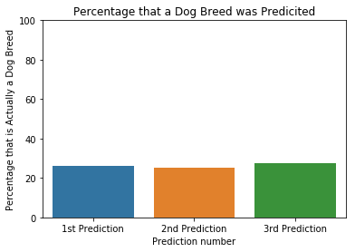

```python
ax = sb.barplot(data = tmp, x = tmp['Prediction number'], y = tmp["Percentage that is Actually a Dog Breed"]*100)
plt.ylim(0, 100);
plt.title('Percentage that a Dog Breed was Predicited');
```

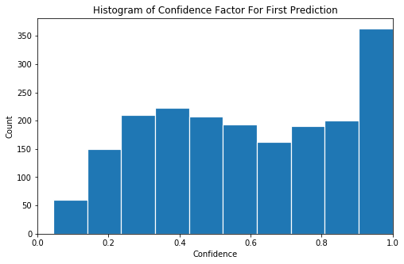

```python
plt.figure(figsize=(8, 5))
plt.xlim(0, 1)
plt.xlabel('Confidence')
plt.ylabel('Count')
plt.hist(x = twitter_archive_master.algo1_conf,
    edgecolor='white', linewidth=1.2)
plt.title('Histogram of Confidence Factor For First Prediction');
```

This chart shows all confidence intervals, including whether the image prediction was actually a breed of dog or not.

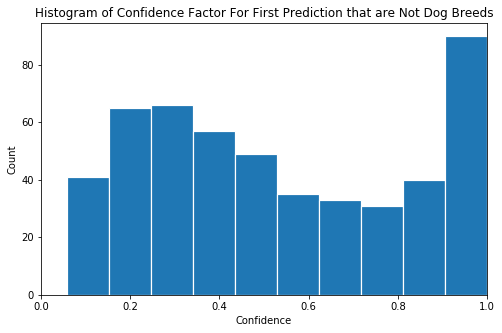

```python
plt.figure(figsize=(8, 5))
plt.xlim(0, 1)
plt.xlabel('Confidence')
plt.ylabel('Count')
plt.hist(x = twitter_archive_master.query("algo1_predicted_breed =='Breed_not_identified'").algo1_conf,
    edgecolor='white', linewidth=1.2)
plt.title('Histogram of Confidence Factor For First Prediction that are Not Dog Breeds');
```

Predictions that are not breeds generally follow the same curve as those that are. It's interesting to see there is a spike at .9-1.0 when the image has definitively been misidentified. It could be the case that an image had a "ball" or some other object in it and that was identified.

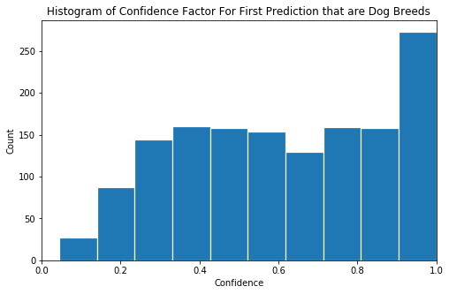

```python
plt.figure(figsize=(8, 5))
plt.xlim(0, 1)
plt.xlabel('Confidence')
plt.ylabel('Count')
plt.hist(x = twitter_archive_master.query("algo1_predicted_breed !='Breed_not_identified'").algo1_conf,
    edgecolor='white', linewidth=1.2)
plt.title('Histogram of Confidence Factor For First Prediction that are Dog Breeds');
```

What do the histograms of the second and third predictions look like?

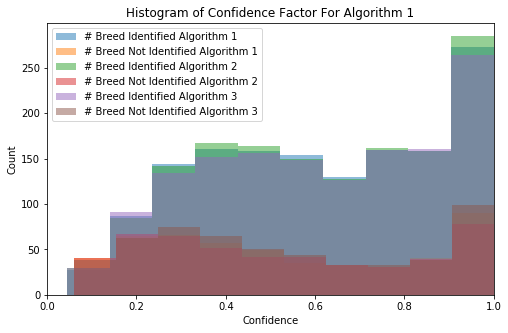

```python
plt.figure(figsize=(8, 5))
plt.xlim(0, 1)
plt.xlabel('Confidence')
plt.ylabel('Count')
plt.hist(x = twitter_archive_master.query("algo1_predicted_breed!='Breed_not_identified'").algo1_conf,
    alpha=.5, label='# Breed Identified Algorithm 1')
plt.hist(x = twitter_archive_master.query("algo1_predicted_breed=='Breed_not_identified'").algo1_conf,
    alpha=.5, label='# Breed Not Identified Algorithm 1')
plt.hist(x = twitter_archive_master.query("algo2_predicted_breed!='Breed_not_identified'").algo1_conf,
    alpha=.5, label='# Breed Identified Algorithm 2')
plt.hist(x = twitter_archive_master.query("algo2_predicted_breed=='Breed_not_identified'").algo1_conf,
    alpha=.5, label='# Breed Not Identified Algorithm 2')
plt.hist(x = twitter_archive_master.query("algo3_predicted_breed!='Breed_not_identified'").algo1_conf,
    alpha=.5, label='# Breed Identified Algorithm 3')
plt.hist(x = twitter_archive_master.query("algo3_predicted_breed=='Breed_not_identified'").algo1_conf,
    alpha=.5, label='# Breed Not Identified Algorithm 3')
plt.title('Histogram of Confidence Factor For Algorithm 1');
plt.legend();
```

The shapes are generally the same for any of the predictions, but the count is higher for the ones where the breed has been identified.

### Which breed of dog is most retweeted?

```python
breed_retweeted = twitter_archive_master[
    twitter_archive_master.algo1_predicted_breed != 'Breed_not_identified']
breed_retweeted = breed_retweeted.groupby(
    'algo1_predicted_breed').sum().reset_index()
breed_retweeted = breed_retweeted[[
    'algo1_predicted_breed', 'retweet_count']]
breed_retweeted = breed_retweeted.sort_values(
    'retweet_count', ascending = False)[0:10]
breed_retweeted
```

|  | algo1_predicted_breed | retweet_count |
| --- | --- | --- |
| 44 | Golden_retriever | 446370.0 |
| 60 | Labrador_retriever | 329728.0 |
| 78 | Pembroke | 262737.0 |
| 26 | Chihuahua | 211564.0 |
| 86 | Samoyed | 163525.0 |
| 40 | French_bulldog | 113394.0 |
| 27 | Chow | 110621.0 |
| 79 | Pomeranian | 101220.0 |
| 29 | Cocker_spaniel | 93390.0 |
| 38 | Eskimo_dog | 91872.0 |

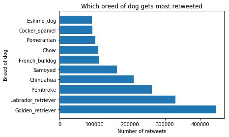

```python
plt.barh(breed_retweeted.algo1_predicted_breed, breed_retweeted.retweet_count);
plt.ylabel('Breed of dog');
plt.xlabel('Number of retweets');
plt.title('Which breed of dog gets most retweeted');
```

Keep in mind, the breed is not actually confirmed with the image, it's just been confirmed that the prediction was a breed of dog. Interesting that retrievers are the top retweet with goldens leading the pack.

### At what time does a tweet get the most favorites?

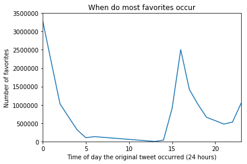

```python
twitter_archive_master.timestamp=pd.to_datetime(twitter_archive_master.timestamp)
tmp = twitter_archive_master[["timestamp","favorite_count"]]
tmp["hour"] = tmp.timestamp.dt.hour
array=tmp.groupby('hour')['favorite_count'].sum()

plt.plot(tmp.groupby('hour')['favorite_count'].sum());
plt.xlabel('Time of day the original tweet occurred (24 hours)');
plt.ylabel('Number of favorites');
plt.title('When do most favorites occur');
plt.xlim(0, 23);
plt.ylim(0, 3500000);
```

A tweet written at midnight gets the most favorites. The next spike is around 4pm. However, it's not easy to interpret the timestamp. From the twitter developer page, timestamp is recorded in UTC (Greenwich) which is the time in London. This is 6 hours ahead of the Central Time Zone. The peak time occurred at midnight (or 6pm CST) and 4pm (10am CST). I decided to leave this in UTC because I travel quite often and it's easier to convert from that timezone. This data does not tell us when the favorite occurred.

## Conclusions

On average there is 2.5 favorites for every retweet.

Golden retrievers were the most retweeted dog followed by laborador retrievers.

A tweet written at midnight (UTC) gets the most favorites. The next spike is around 4pm.

### Limitations

One of the biggest issues with the image identification is that we don't have a confirmation whether or not the predicted breed actually matched the dog pictured. It's concerning that some of the predictions that were not dog breeds, but other objects had a high confidence level of above 0.9. There is a chance that the non-dog object was actually in the image (a ball, paper towel, etc) but one would have expected that the histogram of confidence be more right skewed.

Another issue is with the timezone. The data does not tell us when the favorite occurred, only when the tweet was first published. If WeRateDogs is wanting the chance for the most favorites, they would need to convert the 00:00 and 16:00 to their current timezone. It would be interesting to see the amount of favorites and retweets of all twitter handles at that time had the same trend as WeRateDogs.